# How to Win Premier Lacrosse League Games

**By John Perret**

## Introduction

The [Premier Lacrosse League (PLL)](https://premierlacrosseleague.com) is a relatively new professional sports league. In this project I'd like to see if there is a data science method to find out how to win Premier Lacrosse League Games. If we can find what wins games then teams can focus on that factor in practice to improve their record. Winning games is the main purpose of playing professional sports, so data science could help significantly.

There are only seven teams in the league and only two seasons have been played so far. Due to the lack teams and seasons, the dataset is very small compared to other sports, however, the processes used will scale when more data becomes avaliable

When looking for how to win games we want to focus on things that a team can change or improve on such as increasing shot percentage. A team can not try to improve the year they are playing or their team name

## Data Scrapping

First we'll import all the libraries we'll need as well as initialize some constants that will be used throughout the rest of the tasks.

| Library | Use (for this tutorial) |
| --- | --- |
| [Pandas](https://pandas.pydata.org) | Creating a table from html; storing and accessing data tables |
| [Numpy](https://numpy.org) | General data manipulation; linear regression model creation |
| [Matplotlib.Pyplot](https://matplotlib.org/stable/api/_as_gen/matplotlib.pyplot.html#module-matplotlib.pyplot) | Displaying various graphs/plots. A different library could be used, but I am most comfortable with this one for graping. |
| [Requests](https://pypi.org/project/requests/) | Collecting raw html data from statscrew |
| [bs4 BeautifulSoup](https://www.crummy.com/software/BeautifulSoup/bs4/doc/) | cleaning up html data |
| [sklearn.linear_model](https://scikit-learn.org/stable/modules/linear_model.html) | creating linear regrssion models |

A quick note on numpy vs sklearn for linear regression models: I could've opted to use only one, but for soley style reasons I prefer `numpy` when I intend to plot the regression and `sklearn.linear_model` for printing out the model in english. Either library could bne used instead of the other

```python
import pandas as pd
import numpy as np
import matplotlib.pyplot as plt
import requests as req
from bs4 import BeautifulSoup
from sklearn import linear_model
```

```python
# initialize some constants

# Used when creating graph titles or printing a linear regression model
column_labels = {'PIM' : 'Penalties in minutes', 'Shts': "shots", 'SOG': 'Shots on goal', 'S%': "Shooting Percentage", 'SG%': "Shots on goal percentage", 'GB': "Ground Balls", 'TOC': "Turn overs committed", 'CTO': "Caused Turn overs", 'FO%': "Face off Percentage"}

# Whenever iterating over all seasons, will ease updates when more seasons are available.
SEASONS = [2019, 2020] # as more seasons are held add to the list

# When printing a float, how many decimals to include
DECIMALS_PRINT = 2 # When printing linear regressions, how many decimals
```

### Source

There are multiple pages that data is being scrapped from. They are all from [statscrews.com 2020 Premier Lacrosse League Data](https://www.statscrew.com/lacrosse/l-PLL/y-2020).

[Statscrew.com](https://www.statscrew.com) contains data for many different professional sports leagues and sports.

First we will gather data on all the players in all the season. This requires going to each team's page for each season and scraping the table on the page. Luckily pandas has a function that we can use for scrapping an html table

To differentiate between different teams and seasons we will add a column for each to the dataframe so that we can select the data for a relavant team and or year.

```python
# teams_dic converts team names into the url extension to get data on the team
teams_dic = {"Archers LC" : "t-PLLARC", "Atlas LC" : "t-PLLATL", "Chaos LC" : "t-PLLCHA", "Chrome LC" : "t-PLLCHR", "Redwoods LC" : "t-PLLRED", "Waterdogs LC" : "t-PLLWAT", "Whipsnakes LC" : "t-PLLWHI"}

players_df = pd.DataFrame() # dataframe for players data

for year in SEASONS:
    for team_name in teams_dic:
        # scrape html
        r = req.get(f"https://www.statscrew.com/lacrosse/stats/{teams_dic[team_name]}/y-{year}")
        soup = BeautifulSoup(r.content, 'html.parser')

        # import the first table from the html (second table is goalies)
        new_df = pd.read_html(soup.prettify())[0]

        # add the year and team columns
        new_df['Team'] = team_name
        new_df['Year'] = year

        # add to the players df
        players_df = pd.concat([players_df, new_df],ignore_index=True)

players_df
```

|  | Player | Pos | GP | G | A | Pts | PIM | PPG | SHG | GWG | ... | S% | SG% | GB | TOC | CTO | FO | FW | FO% | Team | Year |
| --- | --- | --- | --- | --- | --- | --- | --- | --- | --- | --- | --- | --- | --- | --- | --- | --- | --- | --- | --- | --- | --- |
| 0 | Tom Schreiber | M | 10.0 | 17.0 | 18.0 | 37.0 | NaN | 0.0 | 0.0 | 0.0 | ... | 28.8 | 58.6 | 9.0 | 22.0 | 1.0 | 0.0 | 0.0 | NaN | Archers LC | 2019 |
| 1 | Marcus Holman | A | 10.0 | 23.0 | 7.0 | 32.0 | NaN | 0.0 | 0.0 | 0.0 | ... | 31.1 | 53.5 | 17.0 | 19.0 | 0.0 | 0.0 | 0.0 | NaN | Archers LC | 2019 |
| 2 | Will Manny | A | 10.0 | 22.0 | 7.0 | 30.0 | NaN | 0.0 | 0.0 | 0.0 | ... | 29.7 | 44.0 | 7.0 | 20.0 | 1.0 | 0.0 | 0.0 | NaN | Archers LC | 2019 |
| 3 | Ben McIntosh | M | 10.0 | 11.0 | 2.0 | 13.0 | NaN | 0.0 | 0.0 | 0.0 | ... | 25.0 | 40.7 | 7.0 | 7.0 | 0.0 | 0.0 | 0.0 | NaN | Archers LC | 2019 |
| 4 | Christian Cuccinello | A | 8.0 | 8.0 | 4.0 | 12.0 | NaN | 0.0 | 0.0 | 0.0 | ... | 28.6 | 47.1 | 10.0 | 7.0 | 0.0 | 0.0 | 0.0 | NaN | Archers LC | 2019 |
| ... | ... | ... | ... | ... | ... | ... | ... | ... | ... | ... | ... | ... | ... | ... | ... | ... | ... | ... | ... | ... | ... |
| 324 | Joe McCallion | M | 6.0 | 0.0 | 0.0 | 0.0 | 0.0 | 0.0 | 0.0 | 0.0 | ... | 0.0 | NaN | 0.0 | 1.0 | 0.0 | 11.0 | 4.0 | 36.4 | Whipsnakes LC | 2020 |
| 325 | Jacob Stover | G | 6.0 | 0.0 | 0.0 | 0.0 | 0.0 | 0.0 | 0.0 | 0.0 | ... | 0.0 | 0.0 | 1.0 | 0.0 | 0.0 | 0.0 | 0.0 | NaN | Whipsnakes LC | 2020 |
| 326 | Tyler Warner | M | 6.0 | 0.0 | 0.0 | 0.0 | 1.5 | 0.0 | 0.0 | 0.0 | ... | 0.0 | 0.0 | 16.0 | 2.0 | 0.0 | 0.0 | 0.0 | NaN | Whipsnakes LC | 2020 |
| 327 | Jake Bernhardt | M,F | 6.0 | 0.0 | 0.0 | 0.0 | 1.0 | 0.0 | 0.0 | 0.0 | ... | 0.0 | 0.0 | 2.0 | 2.0 | 7.0 | 0.0 | 0.0 | NaN | Whipsnakes LC | 2020 |
| 328 | Totals | NaN | 132.0 | 78.0 | 45.0 | 127.0 | 9.5 | 5.0 | 0.0 | 0.0 | ... | 30.2 | 47.6 | 223.0 | 84.0 | 33.0 | 149.0 | 104.0 | 69.8 | Whipsnakes LC | 2020 |

329 rows × 22 columns

This is additional data on the html page for each team. I decided it was easier to copy all the column titles by hand rather than write code to scrape them

| Column Title | Explanation |
| --- | --- |
| Player | Player Name |
| Pos | Position |
| GP | Games Played |
| G | Goals |
| A | Assists |
| Pts | Points = goals + assists |
| PIM | Penalties in minutes |
| PPG | Power Play Goals |
| SHG | Short Hand Goals |
| GWG | Game Winning Goals |
| Shts | Shots |
| SOG | Shots On Goal |
| S% | Shooting Percentage |
| SG% | Shots On Goal Percentage |
| GB | Ground Balls |
| TOC | Turnovers Committed |
| CTO | Caused Turnovers |
| FO | Faceoffs |
| FW | Faceoffs Won |
| FO% | Faceoff Win Percentage |
| Team | Team |
| Year | Year |

Next we will collecting the regular season standings. Similar to the player's data the season data is on a different page for each year. The 2020 season as an example can be found [here](https://www.statscrew.com/lacrosse/standings/l-PLL/y-2020).

```python
teams_df = pd.DataFrame() # empty dataframe to add to

for year in SEASONS:
    r = req.get(f"https://www.statscrew.com/lacrosse/standings/l-PLL/y-{year}")
    soup = BeautifulSoup(r.content, 'html.parser')

    # get the first table on the page
    s = pd.read_html(soup.prettify())[0]

    s['Year'] = year # add year column

    # For some reason the standings page has 2 empty columns at the end of each year's standings table
    s.drop("Unnamed: 5", axis=1, inplace=True)
    s.drop("Unnamed: 6", axis=1, inplace=True)

    # add to standings df
    teams_df = pd.concat([teams_df, s], ignore_index=True)
teams_df
```

|  | Team | W | L | GF | GA | Year |
| --- | --- | --- | --- | --- | --- | --- |
| 0 | Chaos LC | 7 | 3 | 118 | 126 | 2019 |
| 1 | Whipsnakes LC | 6 | 4 | 116 | 109 | 2019 |
| 2 | Archers LC | 5 | 5 | 105 | 100 | 2019 |
| 3 | Redwoods LC | 5 | 5 | 112 | 106 | 2019 |
| 4 | Atlas LC | 5 | 5 | 117 | 122 | 2019 |
| 5 | Chrome LC | 2 | 8 | 120 | 125 | 2019 |
| 6 | Whipsnakes LC | 6 | 0 | 82 | 51 | 2020 |
| 7 | Archers LC | 4 | 2 | 64 | 68 | 2020 |
| 8 | Chrome LC | 3 | 2 | 64 | 64 | 2020 |
| 9 | Redwoods LC | 3 | 3 | 62 | 63 | 2020 |
| 10 | Chaos LC | 2 | 5 | 70 | 78 | 2020 |
| 11 | Waterdogs LC | 1 | 4 | 47 | 53 | 2020 |
| 12 | Atlas LC | 1 | 4 | 46 | 58 | 2020 |

Similar to the players data I decided it would be easier to copy column title explanations by hand

| Column Title | Explanation |
| --- | --- |
| Team | Team |
| W | Wins |
| L | Losses |
| GF | Goals For |
| GA | Goals Against |
| Year | Year |

## Data Tidying

Here we'll do some minor cleanup on the data to make analysis easier later.

To start we'll normalize the data. Since a different number of games were played each season, total goals and number of wins are on a different scale for each season. To combat this we'll use *average* goals per game and winning *percentage* in our analysis.

```python
games_played = (teams_df.W+teams_df.L)
teams_df['games_played'] = games_played

teams_df['win_pct'] = teams_df['W']/games_played
teams_df['avg_gf'] = teams_df['GF']/games_played
teams_df['avg_ga'] = teams_df['GA']/games_played

# To avoid confusion between number of wins and win percentage drop wins and losses columns
# Win and loss counts won't be used.
teams_df.drop(['W', 'L'], axis=1, inplace=True)

teams_df
```

|  | Team | GF | GA | Year | games_played | win_pct | avg_gf | avg_ga |
| --- | --- | --- | --- | --- | --- | --- | --- | --- |
| 0 | Chaos LC | 118 | 126 | 2019 | 10 | 0.700000 | 11.800000 | 12.600000 |
| 1 | Whipsnakes LC | 116 | 109 | 2019 | 10 | 0.600000 | 11.600000 | 10.900000 |
| 2 | Archers LC | 105 | 100 | 2019 | 10 | 0.500000 | 10.500000 | 10.000000 |
| 3 | Redwoods LC | 112 | 106 | 2019 | 10 | 0.500000 | 11.200000 | 10.600000 |
| 4 | Atlas LC | 117 | 122 | 2019 | 10 | 0.500000 | 11.700000 | 12.200000 |
| 5 | Chrome LC | 120 | 125 | 2019 | 10 | 0.200000 | 12.000000 | 12.500000 |
| 6 | Whipsnakes LC | 82 | 51 | 2020 | 6 | 1.000000 | 13.666667 | 8.500000 |
| 7 | Archers LC | 64 | 68 | 2020 | 6 | 0.666667 | 10.666667 | 11.333333 |
| 8 | Chrome LC | 64 | 64 | 2020 | 5 | 0.600000 | 12.800000 | 12.800000 |
| 9 | Redwoods LC | 62 | 63 | 2020 | 6 | 0.500000 | 10.333333 | 10.500000 |
| 10 | Chaos LC | 70 | 78 | 2020 | 7 | 0.285714 | 10.000000 | 11.142857 |
| 11 | Waterdogs LC | 47 | 53 | 2020 | 5 | 0.200000 | 9.400000 | 10.600000 |
| 12 | Atlas LC | 46 | 58 | 2020 | 5 | 0.200000 | 9.200000 | 11.600000 |

From the pages where we scrapped the player data I noticed that each table has a `'Totals'` column that pandas grabbed with all the data for each player. It could be helpful to add the totals rows to the teams table so that we can access the win percentage as well as the sum of all other parameters for each team and season.

```python
# start by selecting all the rows where the player name is 'Totals'
totals_df = players_df.loc[players_df['Player'] == 'Totals']

# Drop any columns where the entire column is empty (ie the player position column)
totals_df = totals_df.dropna(axis=1, how='all')

# Drop the 2019 waterdogs (they didnt exist)
totals_df = totals_df.drop(teams_df.loc[teams_df['Team'] == 'Waterdogs LC'].loc[teams_df['Year'] == 2019].index, axis=0)

# Drop the playername column (each row is 'Totals')
totals_df = totals_df.drop(['Player'], axis=1)

# Add the totals data to the df where team and year match
teams_df = teams_df.merge(totals_df, on=['Team', 'Year'])

# don't need the totals rolls in the players df anymore
players_df.drop(players_df.loc[players_df['Player'] == 'Totals'].index, axis=0, inplace=True)

teams_df
```

|  | Team | GF | GA | Year | games_played | win_pct | avg_gf | avg_ga | GP | G | ... | Shts | SOG | S% | SG% | GB | TOC | CTO | FO | FW | FO% |
| --- | --- | --- | --- | --- | --- | --- | --- | --- | --- | --- | --- | --- | --- | --- | --- | --- | --- | --- | --- | --- | --- |
| 0 | Chaos LC | 118 | 126 | 2019 | 10 | 0.700000 | 11.800000 | 12.600000 | 192.0 | 118.0 | ... | 382.0 | 234.0 | 30.9 | 50.4 | 294.0 | 147.0 | 65.0 | 281.0 | 133.0 | 47.3 |
| 1 | Whipsnakes LC | 116 | 109 | 2019 | 10 | 0.600000 | 11.600000 | 10.900000 | 186.0 | 113.0 | ... | 442.0 | 246.0 | 25.6 | 45.9 | 276.0 | 102.0 | 55.0 | 257.0 | 133.0 | 51.8 |
| 2 | Archers LC | 105 | 100 | 2019 | 10 | 0.500000 | 10.500000 | 10.000000 | 197.0 | 106.0 | ... | 439.0 | 259.0 | 24.1 | 40.9 | 287.0 | 133.0 | 57.0 | 243.0 | 113.0 | 46.5 |
| 3 | Redwoods LC | 112 | 106 | 2019 | 10 | 0.500000 | 11.200000 | 10.600000 | 193.0 | 114.0 | ... | 435.0 | 252.0 | 26.2 | 45.2 | 273.0 | 130.0 | 67.0 | 253.0 | 106.0 | 41.9 |
| 4 | Atlas LC | 117 | 122 | 2019 | 10 | 0.500000 | 11.700000 | 12.200000 | 189.0 | 117.0 | ... | 402.0 | 248.0 | 29.1 | 47.2 | 298.0 | 127.0 | 51.0 | 271.0 | 167.0 | 61.6 |
| 5 | Chrome LC | 120 | 125 | 2019 | 10 | 0.200000 | 12.000000 | 12.500000 | 194.0 | 120.0 | ... | 415.0 | 246.0 | 28.9 | 48.8 | 352.0 | 143.0 | 70.0 | 281.0 | 142.0 | 50.5 |
| 6 | Whipsnakes LC | 82 | 51 | 2020 | 6 | 1.000000 | 13.666667 | 8.500000 | 132.0 | 78.0 | ... | 258.0 | 164.0 | 30.2 | 47.6 | 223.0 | 84.0 | 33.0 | 149.0 | 104.0 | 69.8 |
| 7 | Archers LC | 64 | 68 | 2020 | 6 | 0.666667 | 10.666667 | 11.333333 | 132.0 | 63.0 | ... | 213.0 | 143.0 | 29.6 | 44.1 | 167.0 | 81.0 | 41.0 | 150.0 | 72.0 | 48.0 |
| 8 | Chrome LC | 64 | 64 | 2020 | 5 | 0.600000 | 12.800000 | 12.800000 | 109.0 | 61.0 | ... | 190.0 | 109.0 | 32.1 | 56.0 | 157.0 | 67.0 | 37.0 | 134.0 | 76.0 | 56.7 |
| 9 | Redwoods LC | 62 | 63 | 2020 | 6 | 0.500000 | 10.333333 | 10.500000 | 131.0 | 52.0 | ... | 242.0 | 145.0 | 21.5 | 35.9 | 167.0 | 74.0 | 70.0 | 130.0 | 47.0 | 36.2 |
| 10 | Chaos LC | 70 | 78 | 2020 | 7 | 0.285714 | 10.000000 | 11.142857 | 153.0 | 67.0 | ... | 255.0 | 157.0 | 26.3 | 42.7 | 179.0 | 85.0 | 52.0 | 167.0 | 59.0 | 35.3 |
| 11 | Waterdogs LC | 47 | 53 | 2020 | 5 | 0.200000 | 9.400000 | 10.600000 | 109.0 | 42.0 | ... | 186.0 | 117.0 | 22.6 | 35.9 | 157.0 | 60.0 | 51.0 | 112.0 | 63.0 | 56.3 |
| 12 | Atlas LC | 46 | 58 | 2020 | 5 | 0.200000 | 9.200000 | 11.600000 | 108.0 | 43.0 | ... | 202.0 | 110.0 | 21.3 | 39.1 | 154.0 | 68.0 | 43.0 | 116.0 | 58.0 | 50.0 |

13 rows × 26 columns

## Handling Missing Data

There is some missing data in our tables. There are certain statistics that were not recorded during the first season of play such as penalties in minutes. The Nan's in the dataframe will be okay in further analysis since we know they mean that the data is missing.

Optionally we could've replaced np.nan with pd.na to clarrify that the data is missing and not "not a number", however, for this excersise we know that np.nan represents a missing value.

We wont try to fill in missing data since it is most likely missing soley beacuse nobody thought to record it at the time, not due to a factor in the data itself. Additionally we do not need a data point for every row of every column to perform our analysis, so there is no reason to drop rows/columns or try to fill in data.

## Inital Exploration: Are goals for or goals against more relevant to wins?

To start let's do some simple analysis and determine if scoring goals or stopping goals is more important to winning games. For this exploration lets first graph the data to get an idea of what it looks like.

Ideally when graphing features of a model we create an axis for each feature. Due to the minimal amount of data avaliable I didn't think the 3D graph is very easy to interpret so I also included a 2D graph.

The 3D graph will be useful when there is more datapoints and in a format where the axes can be rotated to view at a different angle.

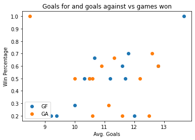

```python
# 2D plot
plt.scatter(teams_df.avg_gf, teams_df.win_pct, label = "GF")
plt.scatter(teams_df.avg_ga, teams_df.win_pct, label = "GA")

plt.legend()

plt.title("Goals for and goals against vs games won")
plt.xlabel("Avg. Goals")
plt.ylabel("Win Percentage")

plt.show()
```

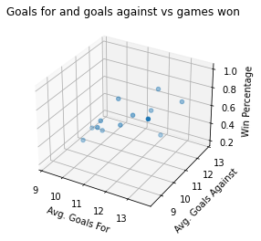

```python
# 3D plot
ax = plt.axes(projection ="3d")

ax.scatter(teams_df.avg_gf, teams_df.avg_ga, teams_df.win_pct)

plt.title("Goals for and goals against vs games won")
ax.set_xlabel("Avg. Goals For")
ax.set_ylabel("Avg. Goals Against")
ax.set_zlabel("Win Percentage")

plt.show()
```

There is not a lot of points to show a clear linear relationship, but we can assume one.

Since we're assuming a linear relationship, lets perform a linear regression for number of wins from goals for and goals against.

```python
X = teams_df[['avg_gf', 'avg_ga']] # drop everything except goals for and against.
y = teams_df.win_pct

num_wins_regr = linear_model.LinearRegression().fit(X, y)

regr_str = f"Win Percentage = {round(num_wins_regr.intercept_, DECIMALS_PRINT)}" \
            + f" + {round(num_wins_regr.coef_[0], DECIMALS_PRINT)} * avg. goals for" \
            + f" + {round(num_wins_regr.coef_[1], DECIMALS_PRINT)} * avg. goals against"
print(regr_str)
```

```
Win Percentage = -0.16 + 0.13 * avg. goals for + -0.07 * avg. goals against
```

By this analysis scoring goals is more important than stopping goals. In other words each goal scored will have a greater impact on the number of wins than each goal scored against. This is not a definite fact, but a conclusion from our data.

## What factors lead to more goals scored?

Since we believe scoring goals to be more important than stopping goals, lets continue our analysis by determining what the most important statistic is for scoring goals.

For this analysis we'll use more of the columns in the players table. We won't use all of the columns in the players dataframe because there are certain things we cannot change. For example, we won't use the position column because we can't have 10 midfielders on the feild at once even if they're the most likely position to be scoring goals.

I will also ignore columns that are dependent on goals. Assists, power play goals and short hand goals do not cause goals but are a result of goals. Assists could potential be explored in further analysis by looking at the effect of assists on shooting percentage.

A list of the columns being used is in the code below

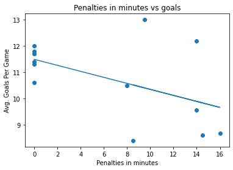

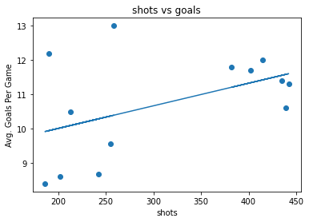

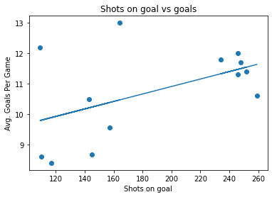

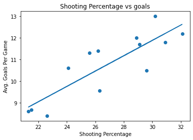

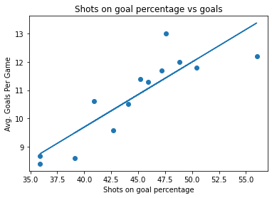

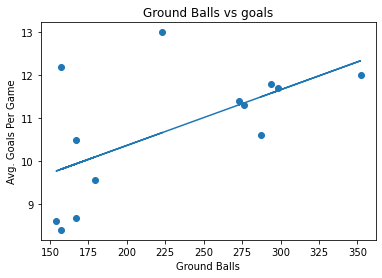

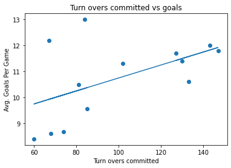

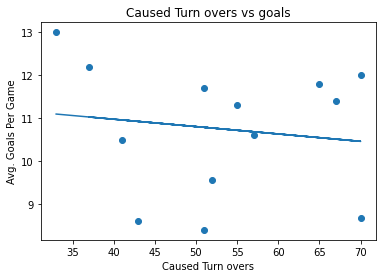

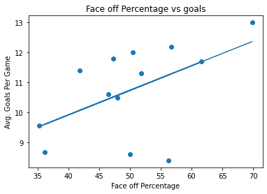

```python
shots_regr_cols = ['PIM', 'Shts', 'SOG', 'S%', 'SG%', 'GB', 'TOC', 'CTO', 'FO%']

# create a dictionary of empty lists to add data to
shots_regr_cols_data = {}
for c in shots_regr_cols:
    shots_regr_cols_data[c] = ([],[])

for year in SEASONS:
    for team_name in teams_dic:
        row = teams_df.loc[teams_df['Team'] == team_name].loc[teams_df['Year'] == year]
        # loc returns a list, there should only be 1 value inside for each team and year.
        # There is at least 1 team year that doesn't have data (waterdogs 2019)
        if len(row) == 1:
            row = row.iloc[0]
            for c in shots_regr_cols:
                if not (np.isnan(row[c]) or np.isnan(row['G'])):
                    shots_regr_cols_data[c][0].append(row[c]) # x data
                    shots_regr_cols_data[c][1].append(row['G']/row['games_played']) # y data

# plot graphs and linear regressions
figure_num = 1
for c in shots_regr_cols:
    plt.figure(figure_num)

    x = shots_regr_cols_data[c][0]
    y = shots_regr_cols_data[c][1]

    # create and plot linear regression for each facter
    m, b = np.polyfit(x, y, 1)
    plt.plot(x, m*np.array(x) + b)

    plt.scatter(x, y)

    plt.title(f'{column_labels[c]} vs goals')
    plt.xlabel(column_labels[c])
    plt.ylabel("Avg. Goals Per Game")

    figure_num += 1
```

Most models have the linear regression we'd expect. There are two graphs that caught my attention. The first being TOC vs goals. In theory more turnovers should lead to less goals since the team committing the turn over no longer has the ball. According to the calculated relationship more turnovers committed is directly related to number of goals scored. This could be due to the fact that if a team has the ball more they will therefore commit more turnovers and turnovers committed doesn't have a direct relationship with goals.

## More complicated linear regression

We could continue looking into what factors help teams score goals, but what we really want to do is figure out what factors lead to a higher win percentage. To do this we'll create a linear regression where the features are all the columns used above in our features vs avg goals regressions.

Again the relationship might not actually be linear, but to keep the model simple and interpretable we will assume a linear relationship.

We could use a more complicated method of machine learning, however, then it might become a blackbox and we might have trouble interpreting what the model actually learned.

```python
X = teams_df[shots_regr_cols]
y = teams_df['win_pct']

num_wins_regr = linear_model.LinearRegression().fit(X, y)

# print regression in a readable format
regr_str = f"Win Percentage = {round(num_wins_regr.intercept_, DECIMALS_PRINT)}"
for i in range(len(num_wins_regr.coef_)):
    regr_str += f" + ({round(num_wins_regr.coef_[i], DECIMALS_PRINT)} * {column_labels[shots_regr_cols[i]]})"
print(regr_str)
```

```
Win Percentage = -5.26 + (0.08 * Penalties in minutes) + (0.05 * shots) + (-0.08 * Shots on goal) + (0.54 * Shooting Percentage) + (-0.3 * Shots on goal percentage) + (-0.01 * Ground Balls) + (0.02 * Turn overs committed) + (0.02 * Caused Turn overs) + (0.05 * Face off Percentage)
```

The regression is hard to interpret since there is not a standard range. For example, 1 penalty minute has a bigger impact on win percentage than 1 shot. Therefore it is difficult to make direct comparisons.

There are some unexpected results in our model. According to the model, shots on goal hurt win percentage, but turn overs committed increases winning percentage. These numbers seem counterintuitive. Especially shots on goal since you can't score a goal without a shot on goal and you can't win games without goals. There could of course be a logical explanation for these oddities, but I would be curious to see if they persist when more data becomes avaliable.

### Residual graph

For our final analysis we'll plot the residuals of the model. We could group residuals by any variable, but I chose year simply because there are the most overlapping data points. Team or another statistic would leave only 1 or 2 datapoints per group.

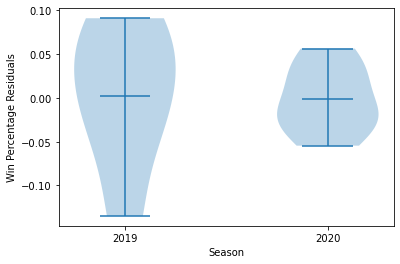

```python
# Calculate residuals
teams_df['residual'] = teams_df['win_pct'] - num_wins_regr.predict(teams_df[shots_regr_cols])

# plot residuals in a violin plot
plt.violinplot([teams_df.loc[teams_df['Year'] == year]['residual'] for year in SEASONS], showmeans=True)

plt.xticks(range(1, len(SEASONS)+1), SEASONS) # adds years at the correct place on x-axis
plt.ylabel('Win Percentage Residuals')
plt.xlabel('Season')
plt.show()
```

## Conclusion

While we were able to make conclusions and predictions about what factors lead to teams winning more games I don't believe that any conclusions are statistically significant due to the lack of data. The graphs of the residuals do not show a normal curve that is expected for a good regression model. Additionally, there were some oddities in the regression model that are most easily explained by a lack of data to train the model.

With this conclusion, I do not claim that the model is wrong but that it doesn't have enough data to prove that it is correct.

After the season this summer there will be more data on the league and we can improve our models. Since the scrapping we did is in loops and not by hand, adding another season and an 8th team to our model should be as simple as adding them to the list of constants at the beginning.

In future work, I think it would be interesting to compare players and see if there is a data science method to determine which players help win the most games (something similar to Moneyball but for lacrosse). Additionally, looking into different types of plays could be beneficial. For example, future analysis could compare assisted vs unassisted goals, aggressive vs conservative defense, the use of [FOGO](https://www.rookieroad.com/lacrosse/what-is-the-fogo-lacrosse-player-position/)'s, etc.

For more information on the Premier Lacrosse League, you can go to https://stats.premierlacrosseleague.com or their main website https://premierlacrosseleague.com. Again all the data I used was scraped from https://www.statscrew.com if you would like to use their data for your own analysis.

Thank you for following along with my analysis of how to win premier lacrosse league games. Whether or not you like lacrosse, I hope the idea of the upcoming season gets you excited thinking about all the additional data that will be available.